# PoC Simulation (unconditional)

Emanuel Sommer

In the following PoC Simulation Study we want to show that given the main assumptions of the approach we can estimate the risk measures correctly. We do this for the unconditional setting. As the conditional simulation from the D-vine is derived rigorously from the Rosenblatt transform and not an approximation the results from this simulation should translate very well to the conditional case.

As a starting point we use data and fitted models from the analysis of Spanish stocks. So for details on the data and the models please have a look at the respective analysis folder and rmarkdown notebook.

## Load the data & packages

```r
# main workhorse for the estimation of risk measures
library(portvine)
# general data wrangling and visualizations
library(tidyverse)
# arrange ggplots nicely
library(patchwork)
# utility color vector for visualizations
custom_colors <- c("#92B8DE", "#db4f59", "#477042", "#cc72d6")
theme_set(
  theme_minimal() +
  theme(plot.title = ggtext::element_markdown(size = 11),
        plot.subtitle = ggtext::element_markdown(size = 9))
)
Sys.setlocale("LC_TIME", "English")
# load the data
load(here::here("data", "msci_spain_data_clean.RData"))
# source utils
source(here::here("analysis_utils.R"))
```

```r
# load the fitted unconditional models
load(here::here("data", "msci_spain_uncond_res.RData"))
```

## Simulation setup

### Marginal ground truths

First we extract the marginal ARMA-GARCH models. Those fittet values are now considered our ground truth. This resembles the assumption that the marginal time series are learnable by ARMA-GARCH models. By using fitted values from ARMA-GARCH models we of course satisfy this assumption by construction. As a quick sanity check we plot the realized time series of log return on top of the fitted series with the raw residuals added on top. The difference which we also compute should be very close to zero.

```r
marginals <- fitted_marginals(uncond_risk_roll_16_19_g50_k25_p500)
```

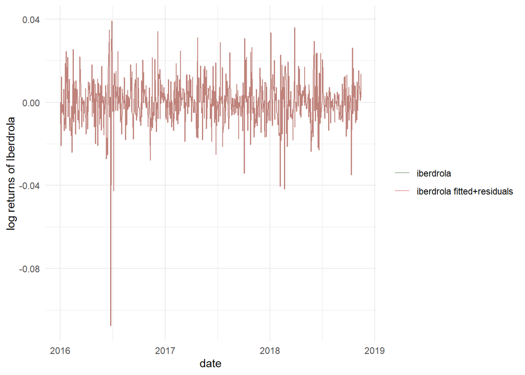

```r
msci_spain_16_19[1:750, ] %>%
  mutate("iberdrola fitted+residuals" =
           as.numeric(
             rugarch::fitted(roll_filtered_model(marginals$iberdrola))
            ) +
           as.numeric(
             rugarch::residuals(
               roll_filtered_model(marginals$iberdrola),
               standardize = FALSE)
          )
  ) %>%
  select(date, iberdrola, `iberdrola fitted+residuals`) %>%
  pivot_longer(-date) %>%
  ggplot(aes(x = date, color = name, y = value)) +
  geom_line(alpha = 0.5) +
  scale_color_manual(values = custom_colors[c(3, 2)]) +
  labs(y = "log returns of Iberdrola", y = "", color = "")
```

```r
msci_spain_16_19[1:750, ] %>%
  mutate("iberdrola_fitted_and_residuals" =
           rugarch::residuals(
             roll_filtered_model(marginals$iberdrola),
             standardize = FALSE
            ) +
           rugarch::fitted(roll_filtered_model(marginals$iberdrola))) %>%
  mutate(abs_diff = abs(iberdrola - iberdrola_fitted_and_residuals)) %>%
  pull(abs_diff) %>%
  mean()
```

```
## [1] 2.891206e-22
```

As we can see the sanity check is passed. As the next step we extract the ground truth series for each asset for our simulation.

```r
ground_truth_series <- msci_spain_16_19[1:750, 3:11]
for (col in colnames(ground_truth_series)) {
  ground_truth_series[col] <- rugarch::fitted(roll_filtered_model(marginals[[col]]))
}
```

### Vine copula i.e. dependence ground truth

As the ground truth for their dependence we take the fitted R-vine copula from the first rolling window. We assume the fitted vine to correctly represent the dependence between the assets. This corresponds to our assumption that the flexible class of vine copulas is able to capture the multivariate dependence between the assets appropriately.

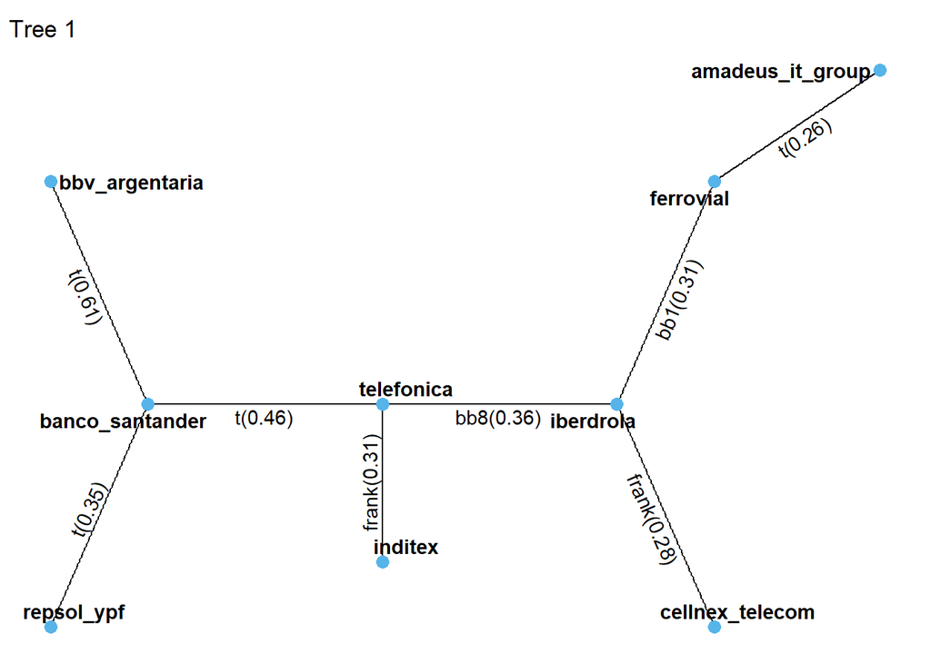

```r
ground_truth_vine <- fitted_vines(uncond_risk_roll_16_19_g50_k25_p500)[[1]]
# visualize first tree
labeled_vinecop_plot(ground_truth_vine)
```

### Simulation approach

- Simulate from the vine copula copula-scale residuals for each asset and each day
- Transform the copula-scale residuals to standardized residuals by applying the inverse PIT with the learned residual distributions
- Use the standardized residuals to retrieve the simulated return series by using the fitted mean and volatility estimates

Having these series we split them into a training and validation window. We now estimate the to be assumed true ES based on the realized values of the series for each day of the validation set. Then we estimate the ES for each of the series using our method and analyze how well our approach compares to the true value. To have a better sample efficiency we have a look at the ES at level $\alpha = 0.1$ and for comparison also $\alpha = 0.05$. Moreover w.l.o.g. we assume an equal weighting for all assets.

In the following we will use a training horizon of $730$ days and a validation horizon of $10$ days. As we need at least one refit we fit twice on a 10 day window. We will take the first to be our evaluation window.

### Simulation

```r
simulate_one_series <- function(ground_truth_portfolio, ground_truth_vine, marginals) {
  copula_scale_resid <- rvinecopulib::rvinecop(750, ground_truth_vine)
  res <- as.data.frame(copula_scale_resid)
  # for each asset retrieve the marginal model and transform
  for (col in colnames(ground_truth_portfolio)) {
    # copula to standardized
    marginal_model <- roll_filtered_model(marginals[[col]])
    roll_distribution <- marginal_model@model$modeldesc$distribution
    skew <- marginals[[col]]@model$coef[[1]]$coef[7, 1]
    shape <- marginals[[col]]@model$coef[[1]]$coef[8, 1]
    res[[col]] <- rugarch::qdist(
      distribution = roll_distribution,
      p = copula_scale_resid[, col],
      skew = skew,
      shape = shape
    )
    # standardized to original scale
    res[[col]] <- ground_truth_portfolio[[col]] + (
      marginal_model@filter$sigma * res[[col]]
    )
  }

  # estimate the ES for the simulated portfolio and record the ES estimates
  risk_roll <- estimate_risk_roll(
    data = res,
    marginal_settings = marginal_settings(
      train_size = 730,
      refit_size = 10
    ),
    vine_settings = vine_settings(
      train_size = 200,
      refit_size = 10,
      family_set = "parametric"
    ),
    alpha = c(0.05, 0.1, 0.2),
    risk_measures = "ES_mean",
    n_samples = 10000,
    trace = FALSE
  )
  risk_estimates <- risk_estimates(risk_roll, alpha = c(0.05, 0.1, 0.2))
  # return both the realized simulated portfolio values as well as the estimated ES estimates for the validation set
  risk_estimates
}

simulate_one_realized_series <- function(ground_truth_portfolio, ground_truth_vine, marginals) {
  copula_scale_resid <- rvinecopulib::rvinecop(750, ground_truth_vine)
  res <- as.data.frame(copula_scale_resid)
  # for each asset retrieve the marginal model and transform
  for (col in colnames(ground_truth_portfolio)) {
    # copula to standardized
    marginal_model <- roll_filtered_model(marginals[[col]])
    roll_distribution <- marginal_model@model$modeldesc$distribution
    skew <- marginals[[col]]@model$coef[[1]]$coef[7, 1]
    shape <- marginals[[col]]@model$coef[[1]]$coef[8, 1]
    res[[col]] <- rugarch::qdist(
      distribution = roll_distribution,
      p = copula_scale_resid[, col],
      skew = skew,
      shape = shape
    )
    # standardized to original scale
    res[[col]] <- ground_truth_portfolio[[col]] + (
      marginal_model@filter$sigma * res[[col]]
    )
  }

  rowSums(res)[731:750]
}
```

```r
realized_returns <- matrix(nrow = 4000, ncol = 20)
colnames(realized_returns) <- paste0("day_", 1:20)
es_0.05_estimates <- realized_returns
es_0.1_estimates <- realized_returns
es_0.2_estimates <- realized_returns

library(progress)
pb <- progress_bar$new(
  format = "  simulating with portvine [:bar] :current/:total (:percent) eta: :eta",
  total = 4000, clear = FALSE
)
for (simulation_number in seq(4000)) {
  pb$tick()
  try({
    simulation <- simulate_one_series(ground_truth_series, ground_truth_vine, marginals)
    realized_returns[simulation_number, ] <- simulation %>%
      filter(alpha == 0.05) %>%
      arrange(row_num) %>%
      pull(realized)
    es_0.05_estimates[simulation_number, ] <- simulation %>%
      filter(alpha == 0.05) %>%
      arrange(row_num) %>%
      pull(risk_est)
    es_0.1_estimates[simulation_number, ] <- simulation %>%
      filter(alpha == 0.1) %>%
      arrange(row_num) %>%
      pull(risk_est)
    es_0.2_estimates[simulation_number, ] <- simulation %>%
      filter(alpha == 0.2) %>%
      arrange(row_num) %>%
      pull(risk_est)
  }, silent = TRUE)

  if ((simulation_number %% 50) == 0) {
    save(
      realized_returns, es_0.05_estimates, es_0.1_estimates, es_0.2_estimates,
      file = here::here("data", "poc_uncond_simulation_exp4.RData")
    )
  }
}

save(
  realized_returns, es_0.05_estimates, es_0.1_estimates, es_0.2_estimates,
  file = here::here("data", "poc_uncond_simulation_exp4.RData")
)
```

The estimation of the true ES will be based on 10000 simulated return series from the ground truth.

```r
realized_returns <- matrix(nrow = 10000, ncol = 20)
pb <- progress_bar$new(
  format = "  simulating realized returns [:bar] :current/:total (:percent) eta: :eta",
  total = 10000, clear = FALSE
)
for (i in seq(10000)) {
  pb$tick()
  realized_returns[i, ] = simulate_one_realized_series(
    ground_truth_series, ground_truth_vine, marginals
  )
}
```

### Evaluation

```r
load(here::here("data", "poc_uncond_simulation_exp4.RData"))
```

Estimate the *true* ES first.

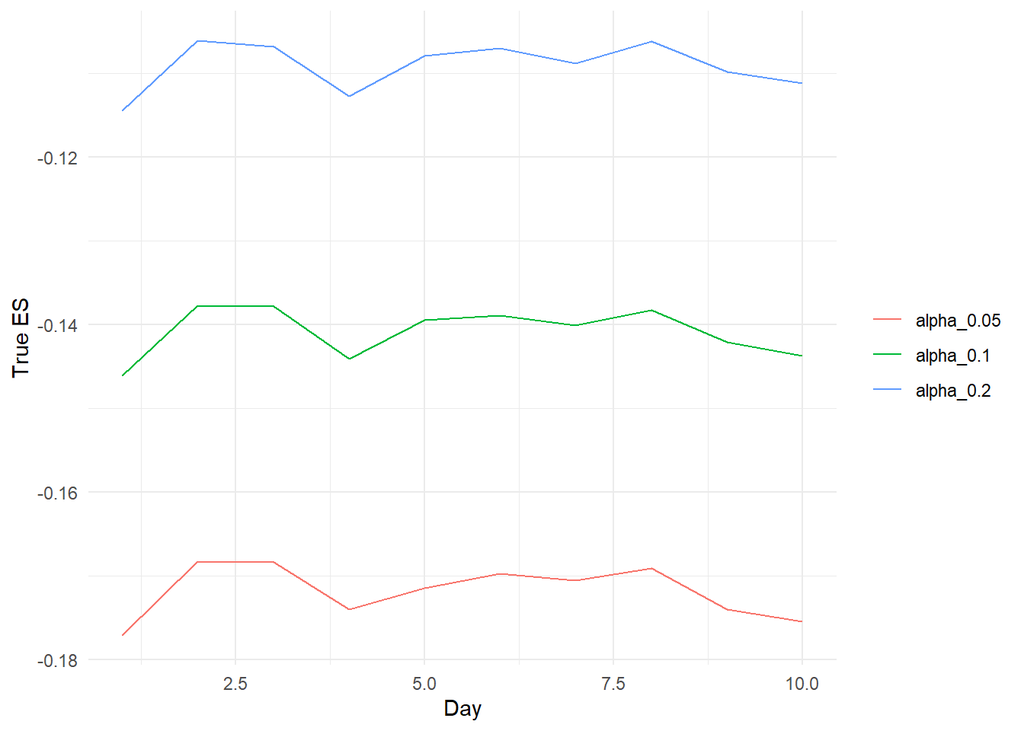

```r
true_es <- vapply(1:10, function(day) {
  est_es(realized_returns[, day], alpha = c(0.2, 0.1, 0.05))
}, FUN.VALUE = numeric(3))
rownames(true_es) <- c("alpha_0.2", "alpha_0.1", "alpha_0.05")
t(true_es) %>%
  as_tibble() %>%
  mutate(day = (1:10)) %>%
  pivot_longer(-day) %>%
  ggplot(aes(x = day, y = value, col = name)) +
  geom_line() +
  labs(x = "Day", y = "True ES", col = "")
```

Distribution of the ES estimates for one day only.

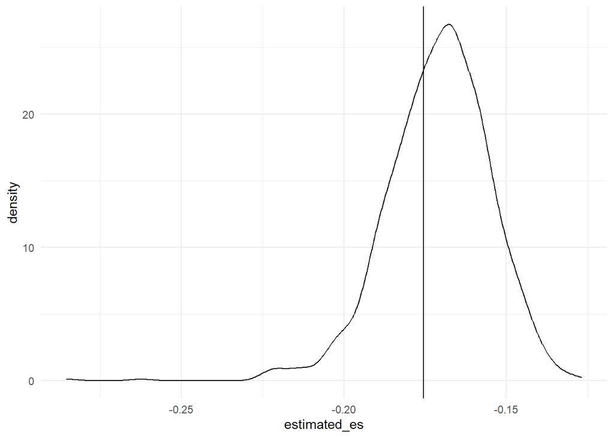

```r
tibble(
  true_es = true_es[3, 10],
  estimated_es = es_0.05_estimates[, 10]
) %>%
  ggplot() +
  geom_density(aes(x = estimated_es)) +
  geom_vline(aes(xintercept = true_es))
```

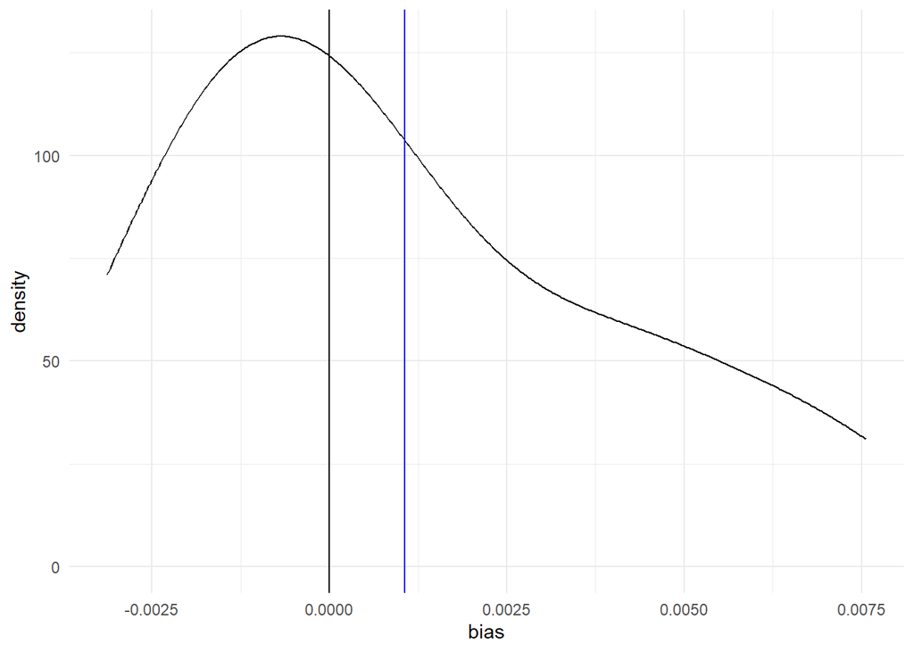

```r
# Have a look at the bias w.r.t. the mean of ES estimates
bias_0.1 <- colMeans(es_0.1_estimates) - true_es[2, ]
tibble(bias = bias_0.1) %>%
  ggplot(aes(x = bias)) +
  geom_density() +
  geom_vline(xintercept = mean(bias_0.1), col = "blue") +
  geom_vline(xintercept = 0)
```

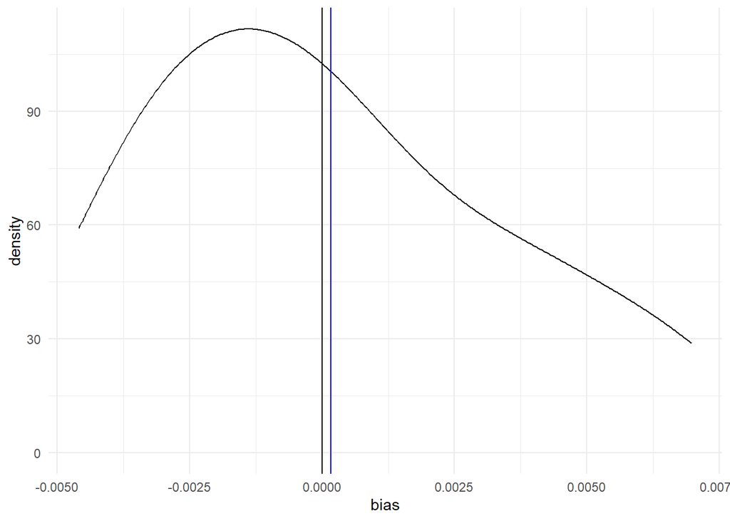

```r
bias_0.05 <- colMeans(es_0.05_estimates) - true_es[3, ]
tibble(bias = bias_0.05) %>%
  ggplot(aes(x = bias)) +
  geom_density() +
  geom_vline(xintercept = mean(bias_0.05), col = "blue") +
  geom_vline(xintercept = 0)
```

```r
# standard deviation for comparison
sd(realized_returns)
```

```
## [1] 0.08333808
```

Compared to he base variablilty the bias is a really small one.

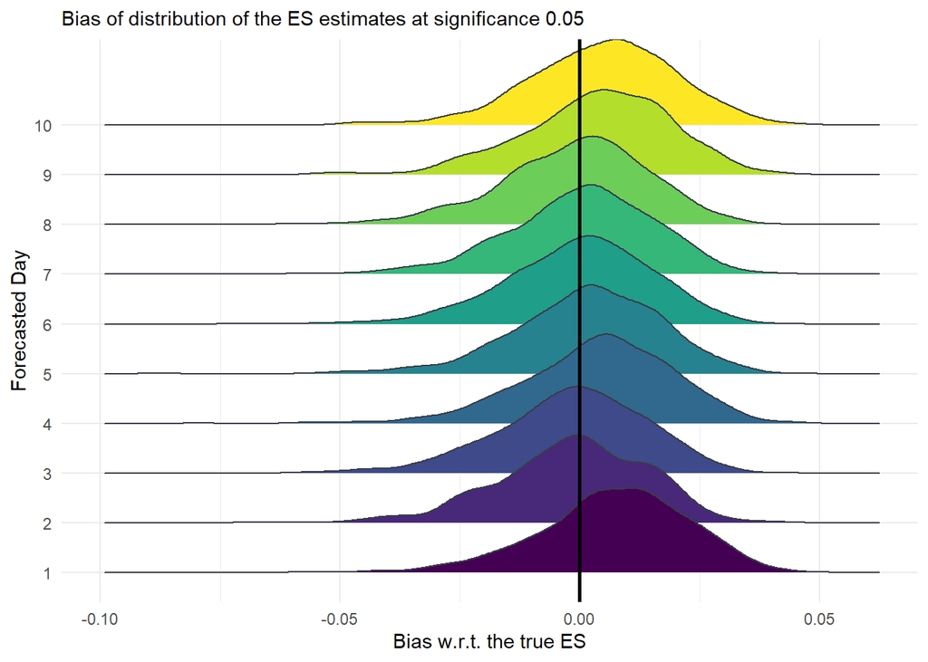

```r
t(t(es_0.05_estimates[, 1:10]) - true_es[3, ]) %>%
  as_tibble() %>%
  pivot_longer(everything(), names_to = "day", values_to = "bias") %>%
  mutate(day = as.factor(as.integer(str_remove(day, "day_")))) %>%
  group_by(day) %>%
  mutate(p_value = pnorm(mean(bias), mean = 0, sd = sd(bias))) %>%
  ggplot() +
  ggridges::geom_density_ridges(
    aes(x = bias, y = day, fill = day), col = "#383d47", na.rm = TRUE
  ) +
  geom_vline(xintercept = 0, linewidth = 1) +
  scale_fill_viridis_d() +
  scale_color_viridis_d() +
  guides(color = "none", fill = "none") +
  xlim(-0.1, NA) +
  labs(
    x = "Bias w.r.t. the true ES", y = "Forecasted Day",
    title = "Bias of distribution of the ES estimates at significance 0.05"
  )
```

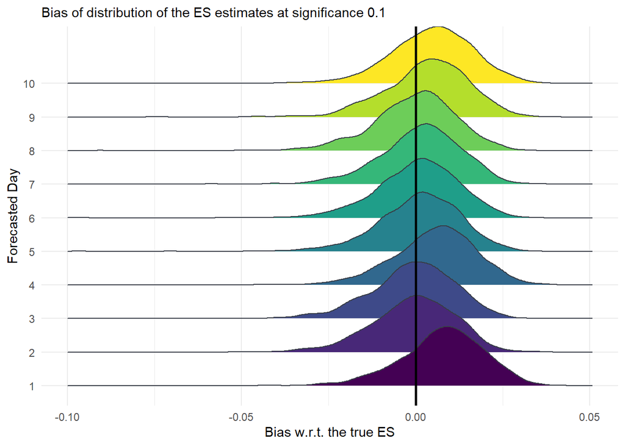

```r
t(t(es_0.1_estimates[, 1:10]) - true_es[2, ]) %>%
  as_tibble() %>%
  pivot_longer(everything(), names_to = "day", values_to = "bias") %>%
  mutate(day = as.factor(as.integer(str_remove(day, "day_")))) %>%
  ggplot() +
  ggridges::geom_density_ridges(
    aes(x = bias, y = day, fill = day), col = "#383d47", na.rm = TRUE
  ) +
  geom_vline(xintercept = 0, linewidth = 1) +
  scale_fill_viridis_d() +
  scale_color_viridis_d() +
  guides(color = "none", fill = "none") +
  xlim(-0.1, NA) +
  labs(
    x = "Bias w.r.t. the true ES", y = "Forecasted Day",
    title = "Bias of distribution of the ES estimates at significance 0.1"
  )
```

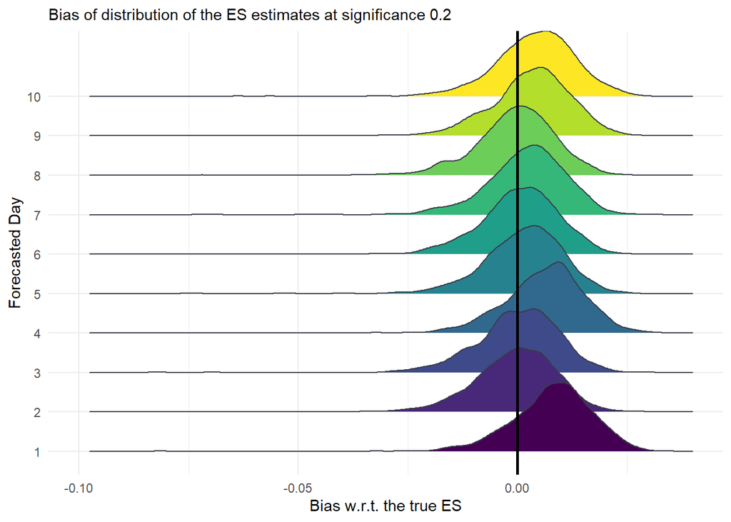

```r
t(t(es_0.2_estimates[, 1:10]) - true_es[1, ]) %>%
  as_tibble() %>%
  pivot_longer(everything(), names_to = "day", values_to = "bias") %>%
  mutate(day = as.factor(as.integer(str_remove(day, "day_")))) %>%
  ggplot() +
  ggridges::geom_density_ridges(
    aes(x = bias, y = day, fill = day), col = "#383d47", na.rm = TRUE
  ) +
  geom_vline(xintercept = 0, linewidth = 1) +
  scale_fill_viridis_d() +
  scale_color_viridis_d() +
  guides(color = "none", fill = "none") +
  xlim(-0.1, NA) +
  labs(
    x = "Bias w.r.t. the true ES", y = "Forecasted Day",
    title = "Bias of distribution of the ES estimates at significance 0.2"
  )
```